# Subste Selectiona and Regularization

Silvia Salini

11/5/2021

# Crime Data Set

2005 Statewide Crime dataset. Agresti and Finlay book ’Statistical Method for Social Sciences’. The variables for this data set are: VI = violent crime rate (number of violent crimes per 100,000 population), VI2 = violent crime rate (number of violent crimes per 10,000 population), MU = murder rate, ME = percent in metropolitan areas, WH = percent white, HS = percent high school graduates, PO = percent below the poverty level. The data are from Statistical Abstract of the United States. The units are 51, the 50 states of United States plus the District of Columbia (or Washington D.C.).

```r
library(smss)
data("crime2005")
summary(crime2005[,-c(1,2)])
```

```
##       VI2               MU               ME               WH
##  Min.   :  8.00   Min.   : 1.000   Min.   : 38.20   Min.   :26.50
##  1st Qu.: 27.00   1st Qu.: 3.000   1st Qu.: 60.80   1st Qu.:76.10
##  Median : 37.00   Median : 5.000   Median : 71.60   Median :85.20
##  Mean   : 42.59   Mean   : 5.569   Mean   : 72.25   Mean   :81.64
##  3rd Qu.: 53.00   3rd Qu.: 6.000   3rd Qu.: 86.80   3rd Qu.:90.35
##  Max.   :161.00   Max.   :44.000   Max.   :100.00   Max.   :97.00
##        HS              PO
##  Min.   :78.30   Min.   : 5.100
##  1st Qu.:84.00   1st Qu.: 7.300
##  Median :87.20   Median : 8.500
##  Mean   :86.46   Mean   : 9.506
##  3rd Qu.:88.80   3rd Qu.:10.750
##  Max.   :92.30   Max.   :18.500
```

```r
library(car)
```

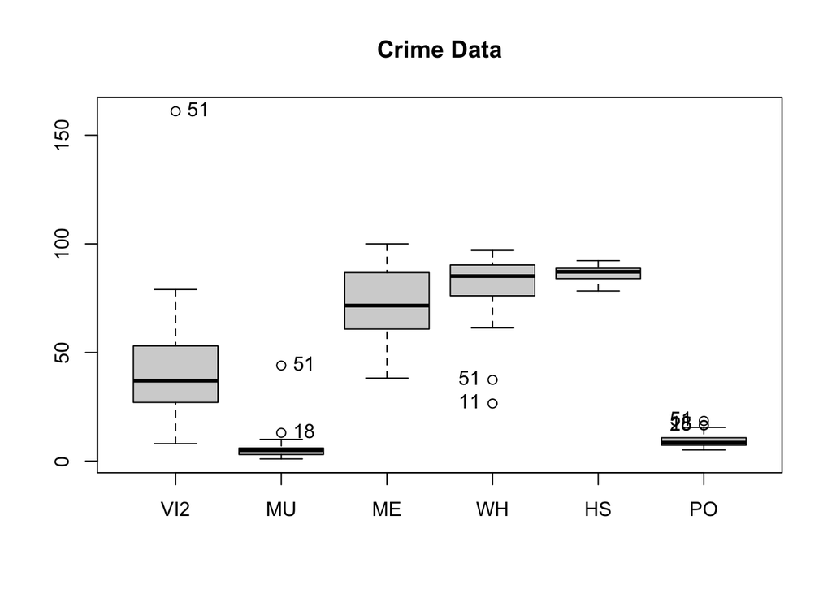

```
## [1] "51" "18" "51" "11" "51" "18" "25" "51"
```

```r
Boxplot(crime2005[,-c(1,2)], main="Crime Data")
```

There are outliers, so before we proceed we will remove them:

```r
crime2005<-crime2005[which(crime2005$VI2<100),]
summary(crime2005[,-c(1,2)])
```

```
##       VI2              MU             ME              WH              HS
##  Min.   : 8.00   Min.   : 1.0   Min.   :38.20   Min.   :26.50   Min.   :78.30
##  1st Qu.:27.00   1st Qu.: 3.0   1st Qu.:60.65   1st Qu.:76.97   1st Qu.:83.80
##  Median :36.50   Median : 5.0   Median :71.50   Median :85.25   Median :87.30
##  Mean   :40.22   Mean   : 4.8   Mean   :71.69   Mean   :82.52   Mean   :86.46
##  3rd Qu.:51.00   3rd Qu.: 6.0   3rd Qu.:85.70   3rd Qu.:90.38   3rd Qu.:88.80
##  Max.   :79.00   Max.   :13.0   Max.   :94.40   Max.   :97.00   Max.   :92.30
##        PO
##  Min.   : 5.100
##  1st Qu.: 7.300
##  Median : 8.450
##  Mean   : 9.326
##  3rd Qu.:10.700
##  Max.   :16.600
```

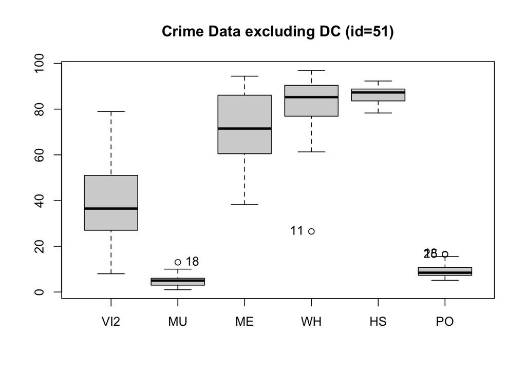

```
## [1] "18" "11" "18" "25"
```

```r
Boxplot(crime2005[,-c(1,2)], main="Crime Data excluding DC (id=51)")
```

# Linear Regression

```r
rownames(crime2005)<-crime2005$STATE
dati<-crime2005[,-c(1,2)]
mod<-lm(VI2~.,data=dati)
summary(mod)
```

```
##
## Call:
## lm(formula = VI2 ~ ., data = dati)
##
## Residuals:
##     Min      1Q  Median      3Q     Max
## -17.677  -7.797  -2.250   2.304  31.119
##
## Coefficients:
##             Estimate Std. Error t value Pr(>|t|)
## (Intercept)  94.2157    76.3241   1.234   0.2236
## MU            3.9656     0.9205   4.308 9.09e-05 ***
## ME            0.3130     0.1315   2.380   0.0217 *
## WH           -0.0592     0.1605  -0.369   0.7141
## HS           -0.9814     0.7595  -1.292   0.2031
## PO           -0.6140     1.0542  -0.582   0.5633
## ---
## Signif. codes:  0 '***' 0.001 '**' 0.01 '*' 0.05 '.' 0.1 ' ' 1
##
## Residual standard error: 11.84 on 44 degrees of freedom
## Multiple R-squared:  0.5912, Adjusted R-squared:  0.5447
## F-statistic: 12.73 on 5 and 44 DF,  p-value: 1.139e-07
```

```r
library(car)
vif(mod)
```

```
##       MU       ME       WH       HS       PO
## 1.956819 1.341286 1.384481 2.688856 3.226042
```

```r
sqrt(vif(mod))>1.5
```

```
##    MU    ME    WH    HS    PO
## FALSE FALSE FALSE  TRUE  TRUE
```

## Best Subset regression

We will now use the package `leaps` to evaluate all the best-subset models.

```r
library(leaps)
regfit.full=regsubsets(VI2~.,data=dati)
reg.summary=summary(regfit.full)
names(reg.summary)
```

```
## [1] "which"  "rsq"    "rss"    "adjr2"  "cp"     "bic"    "outmat" "obj"
```

```r
plot(reg.summary$cp,xlab="Number of Variables",ylab="Cp")
which.min(reg.summary$cp)
```

```
## [1] 2
```

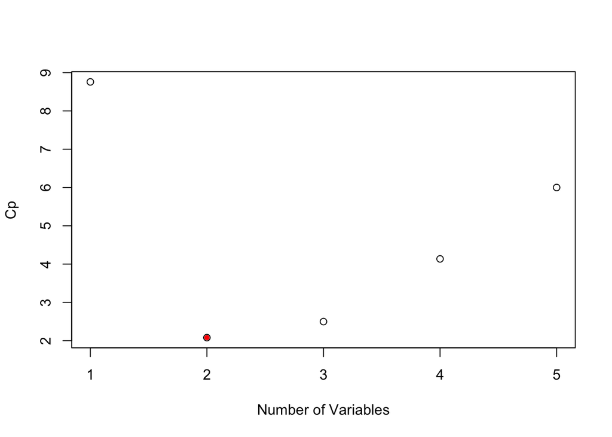

```r
points(2,reg.summary$cp[2],pch=20,col="red")
```

There is a plot method for the `regsubsets` object

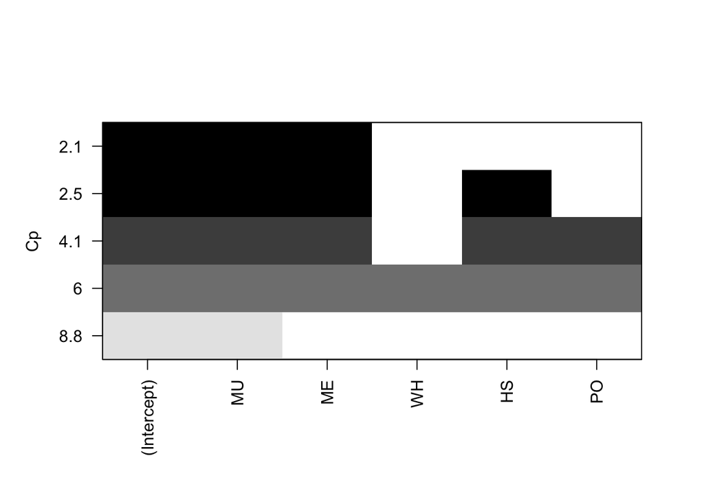

```r
plot(regfit.full,scale="Cp")
```

```r
coef(regfit.full,2)
```

```
## (Intercept)          MU          ME
##  -5.4683720   4.4483255   0.3394483
```

## Forward Stepwise Selection

Here we use the `regsubsets` function but specify the `method=“forward” option:

```r
regfit.fwd=regsubsets(VI2~.,data=dati,method="forward")
summary(regfit.fwd)
```

```
## Subset selection object
## Call: regsubsets.formula(VI2 ~ ., data = dati, method = "forward")
## 5 Variables  (and intercept)
##    Forced in Forced out
## MU     FALSE      FALSE
## ME     FALSE      FALSE
## WH     FALSE      FALSE
## HS     FALSE      FALSE
## PO     FALSE      FALSE
## 1 subsets of each size up to 5
## Selection Algorithm: forward
##          MU  ME  WH  HS  PO
## 1  ( 1 ) "*" " " " " " " " "
## 2  ( 1 ) "*" "*" " " " " " "
## 3  ( 1 ) "*" "*" " " "*" " "
## 4  ( 1 ) "*" "*" " " "*" "*"
## 5  ( 1 ) "*" "*" "*" "*" "*"
```

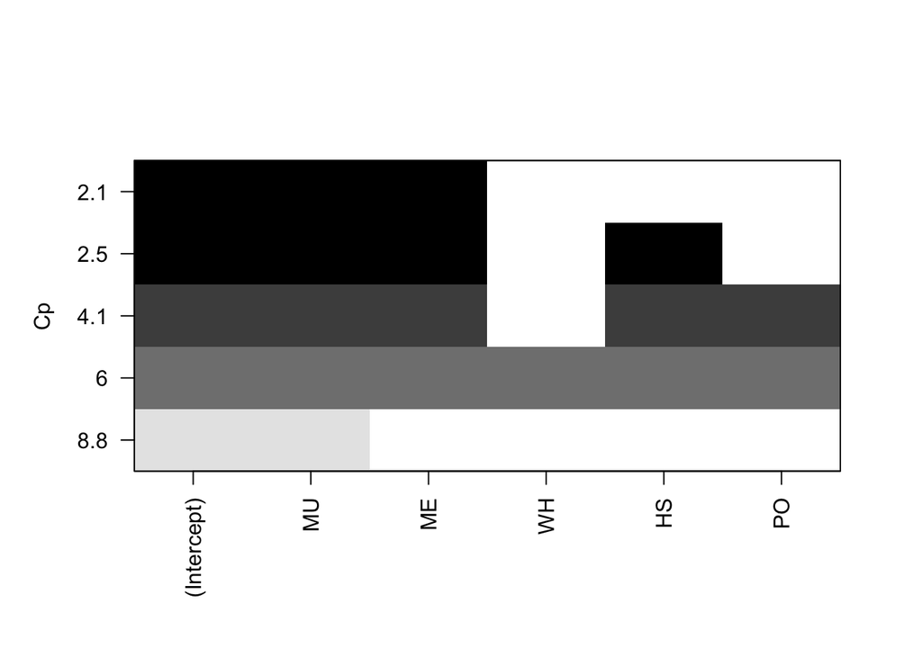

```r
plot(regfit.fwd,scale="Cp")
```

## Model Selection Using a Validation Set

Lets make a training and validation set, so that we can choose a good subset model. We will do it using a slightly different approach from what was done in the the book.

```r
dim(dati)
```

```
## [1] 50  6
```

```r
set.seed(1)
train=sample(seq(50),25,replace=FALSE)
train
```

```
##  [1]  4 39  1 34 23 43 14 18 33 21 41 10  7  9 15 40 25 47 12 36 48 20  3  6 49
```

```r
regfit.fwd=regsubsets(VI2~.,data=dati[train,],method="forward")
```

Now we will make predictions on the observations not used for training. We know there are 5 models, so we set up some vectors to record the errors. We have to do a bit of work here, because there is no predict method for `regsubsets`.

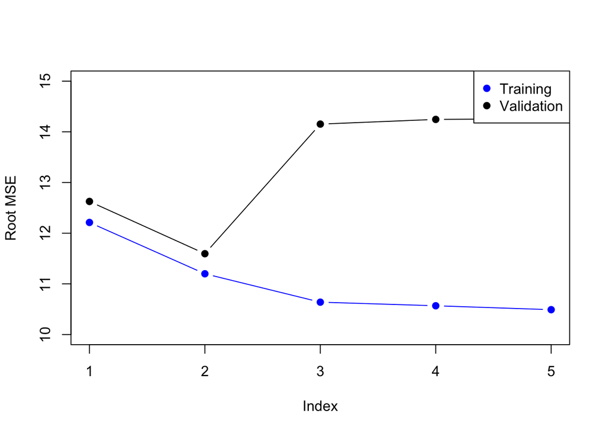

```r
val.errors=rep(NA,5)
x.test=model.matrix(VI2~.,data=dati[-train,])
y.test=dati$VI2[-train]
for(i in 1:5){
  coefi=coef(regfit.fwd,id=i)
  pred=x.test[,names(coefi)]%*%coefi
  val.errors[i]=mean((dati$VI2[-train]-pred)^2)
}
plot(sqrt(val.errors),ylab="Root MSE",ylim=c(10,15),pch=19,type="b")
points(sqrt(regfit.fwd$rss[-1]/25),col="blue",pch=19,type="b")
legend("topright",legend=c("Training","Validation"),col=c("blue","black"),pch=19)
```

As we expect, the training error goes down monotonically as the model gets bigger, but not so for the validation error.

We need a function in order to do predict for `regsubsets`

```r
predict.regsubsets=function(object,newdata,id,...){
  form=as.formula(object$call[[2]])
  mat=model.matrix(form,newdata)
  coefi=coef(object,id=id)
  mat[,names(coefi)]%*%coefi
}
```

## Model Selection by Cross-Validation

We will do 10-fold cross-validation. Its really easy!

```r
set.seed(11)
folds=sample(rep(1:10,length=nrow(dati)))
folds
```

```
##  [1]  4  5  6  7  2  1  2 10  9  3  5  5  9 10  1  6  3  8  6  8  2  7 10  8  6
## [26]  1  1  9  8  7  4 10  3  7  5  2  4  7  4  9  1  2  5  3  3  4  6  8 10  9
```

```r
table(folds)
```

```
## folds
##  1  2  3  4  5  6  7  8  9 10
##  5  5  5  5  5  5  5  5  5  5
```

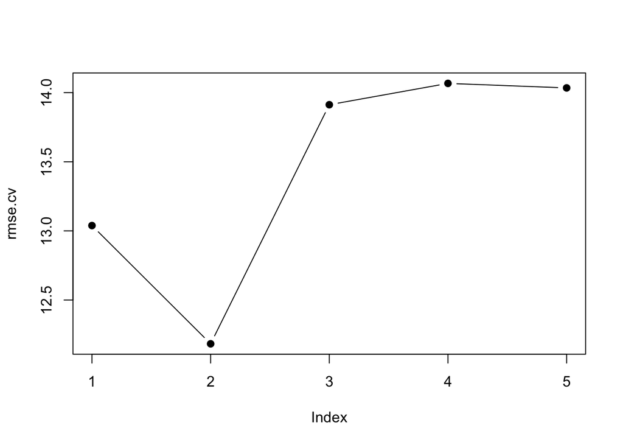

```r
cv.errors=matrix(NA,10,5)
for(k in 1:10){
  best.fit=regsubsets(VI2~.,data=dati[folds!=k,],method="forward")
  for(i in 1:5){
    pred=predict(best.fit,dati[folds==k,],id=i)
    cv.errors[k,i]=mean( (dati$VI2[folds==k]-pred)^2)
  }
}
rmse.cv=sqrt(apply(cv.errors,2,mean))
plot(rmse.cv,pch=19,type="b")
```

## Ridge Regression and the Lasso

We will use the package `glmnet`, which does not use the model formula language, so we will set up an `x` and `y`.

```r
library(glmnet)
x=model.matrix(VI2~.-1,data=dati)
y=dati$VI2
```

First we will fit a ridge-regression model. This is achieved by calling `glmnet` with `alpha=0` (see the helpfile). There is also a `cv.glmnet` function which will do the cross-validation for us.

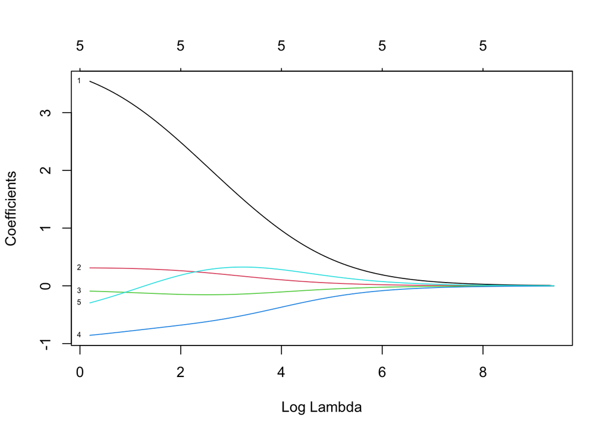

```r
fit.ridge=glmnet(x,y,alpha=0)
plot(fit.ridge,xvar="lambda",label=TRUE)
```

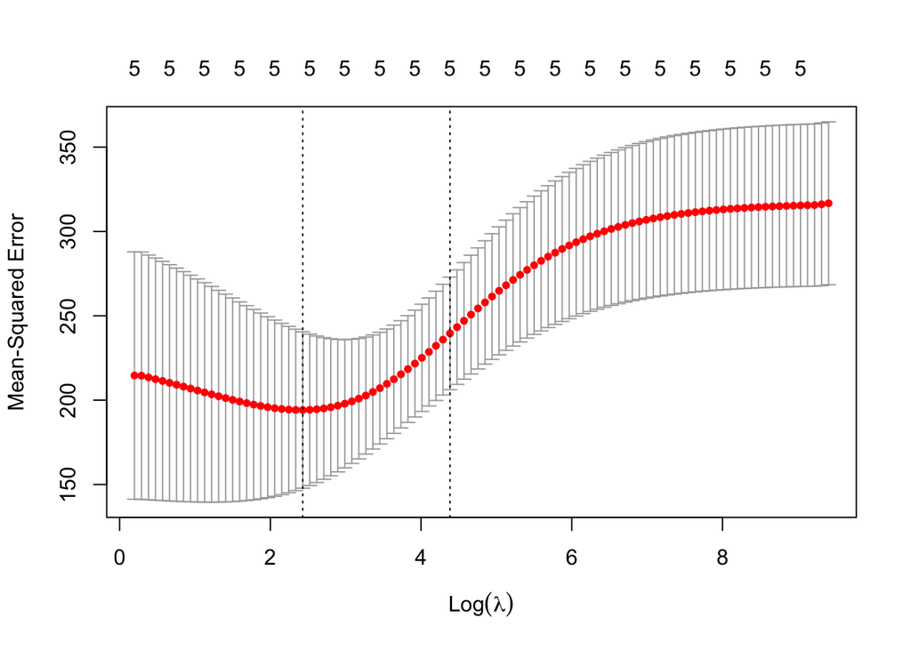

```r
cv.ridge=cv.glmnet(x,y,alpha=0)
plot(cv.ridge)
```

```r
coef(cv.ridge)
```

```
## 6 x 1 sparse Matrix of class "dgCMatrix"
##                       1
## (Intercept) 61.48378125
## MU           0.73657103
## ME           0.07857917
## WH          -0.08516298
## HS          -0.29631321
## PO           0.23751843
```

Now we fit a lasso model; for this we use the default `alpha=1`

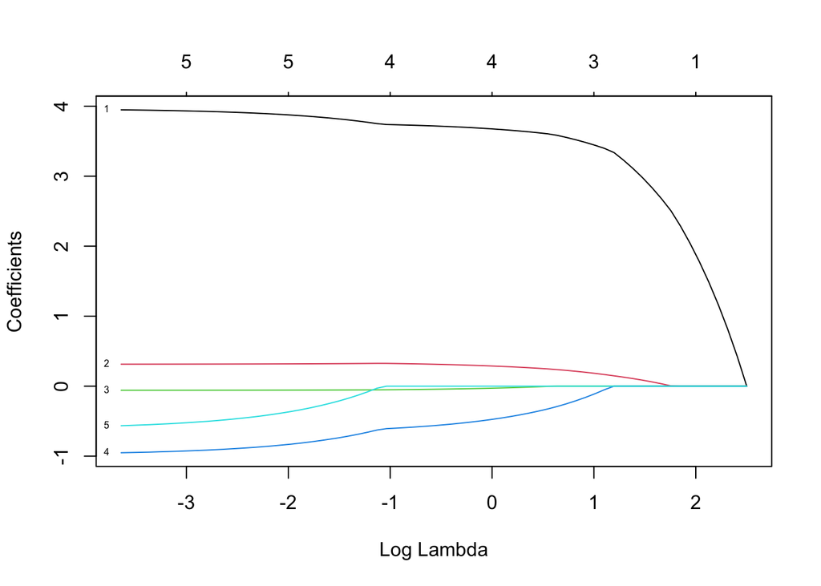

```r
fit.lasso=glmnet(x,y)
plot(fit.lasso,xvar="lambda",label=TRUE)
```

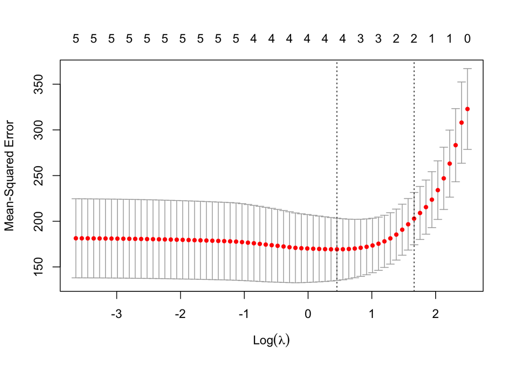

```r
cv.lasso=cv.glmnet(x,y)
plot(cv.lasso)
```

```r
coef(cv.lasso)
```

```
## 6 x 1 sparse Matrix of class "dgCMatrix"
##                       1
## (Intercept) 24.90338056
## MU           2.67952545
## ME           0.03424132
## WH           .
## HS           .
## PO           .
```

Suppose we want to use our earlier train/validation division to select the `lambda` for the lasso. This is easy to do.

```r
lasso.tr=glmnet(x[train,],y[train])
lasso.tr
```

```
##
## Call:  glmnet(x = x[train, ], y = y[train])
##
##    Df  %Dev  Lambda
## 1   0  0.00 13.4400
## 2   1  9.30 12.2500
## 3   1 17.02 11.1600
## 4   1 23.43 10.1700
## 5   1 28.76  9.2650
## 6   2 33.43  8.4420
## 7   2 37.52  7.6920
## 8   2 40.92  7.0080
## 9   2 43.73  6.3860
## 10  3 46.91  5.8190
## 11  3 50.10  5.3020
```

[output cut: 57 more lines]

```r
pred=predict(lasso.tr,x[-train,])
dim(pred)
```

```
## [1] 25 68
```

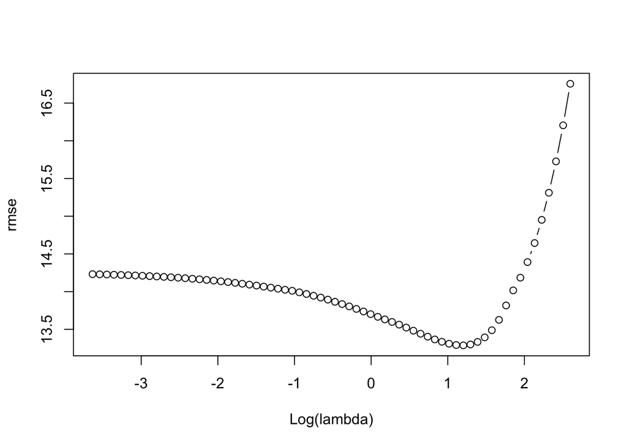

```r
rmse= sqrt(apply((y[-train]-pred)^2,2,mean))
plot(log(lasso.tr$lambda),rmse,type="b",xlab="Log(lambda)")
```

```r
lam.best=lasso.tr$lambda[order(rmse)[1]]
lam.best
```

```
## [1] 3.329589
```

```r
coef(lasso.tr,s=lam.best)
```

```
## 6 x 1 sparse Matrix of class "dgCMatrix"
##                      1
## (Intercept) 45.1245017
## MU           2.2943104
## ME           0.1613238
## WH          -0.3251678
## HS           .
## PO           .
```

# Principal Component Regression and Partial Least Square Regression

```r
library(pls)
set.seed(2)
pcr.fit=pcr(VI2~.,data=dati,scale=TRUE,validation="CV")
summary(pcr.fit)
```

```
## Data:    X dimension: 50 5
##  Y dimension: 50 1
## Fit method: svdpc
## Number of components considered: 5
##
## VALIDATION: RMSEP
## Cross-validated using 10 random segments.
##        (Intercept)  1 comps  2 comps  3 comps  4 comps  5 comps
## CV           17.73    14.36    13.45    13.75    14.01    13.97
## adjCV        17.73    14.32    13.39    13.67    13.83    13.79
##
## TRAINING: % variance explained
##      1 comps  2 comps  3 comps  4 comps  5 comps
## X      49.35    75.83    88.13    96.26   100.00
## VI2    37.92    51.56    53.26    57.97    59.12
```

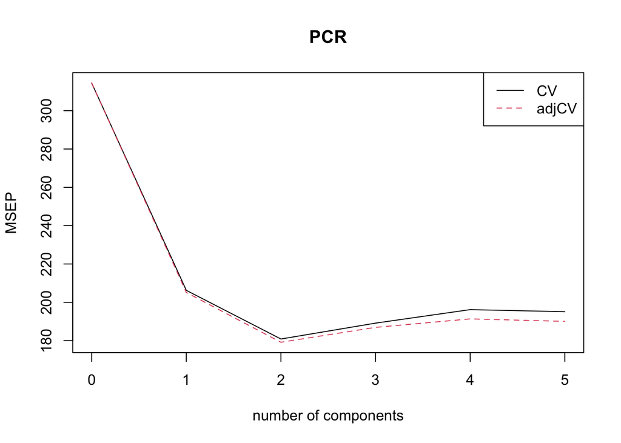

```r
validationplot(pcr.fit,val.type="MSEP",legendpos = "topright", main="PCR")
```

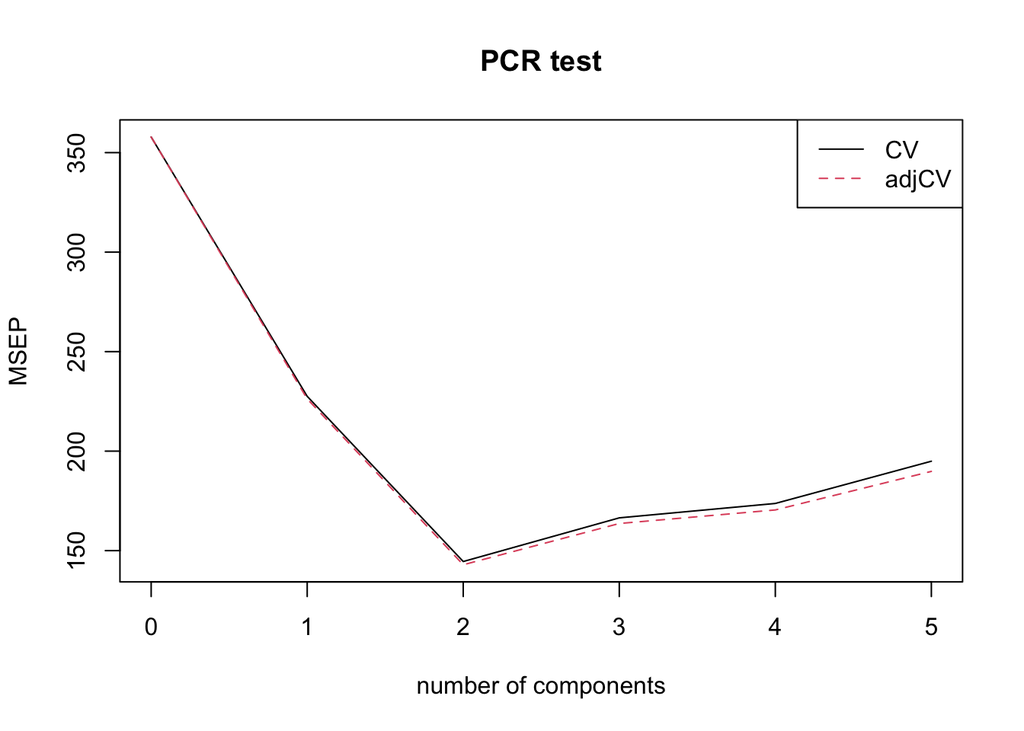

```r
set.seed(1)
pcr.fit=pcr(VI2~.,data=dati, subset=train,scale=TRUE, validation="CV")
validationplot(pcr.fit,val.type="MSEP",legendpos = "topright", main="PCR test")
```

```r
pcr.pred=predict(pcr.fit,x[-train,],ncomp=2)
mean((pcr.pred-y[-train])^2)
```

```
## [1] 208.8286
```

```r
pcr.fit=pcr(y~x,scale=TRUE,ncomp=2)
summary(pcr.fit)
```

```
## Data:    X dimension: 50 5
##  Y dimension: 50 1
## Fit method: svdpc
## Number of components considered: 2
## TRAINING: % variance explained
##    1 comps  2 comps
## X    49.35    75.83
## y    37.92    51.56
```

```r
set.seed(1)
pls.fit=plsr(VI2~.,data=dati, subset=train, scale=TRUE, validation="CV")
summary(pls.fit)
```

```
## Data:    X dimension: 25 5
##  Y dimension: 25 1
## Fit method: kernelpls
## Number of components considered: 5
##
## VALIDATION: RMSEP
## Cross-validated using 10 random segments.
##        (Intercept)  1 comps  2 comps  3 comps  4 comps  5 comps
## CV           18.92    12.83    12.71    14.10    13.95    13.96
## adjCV        18.92    12.82    12.62    13.89    13.77    13.78
##
## TRAINING: % variance explained
##      1 comps  2 comps  3 comps  4 comps  5 comps
## X      48.93    79.24    82.51    95.96   100.00
## VI2    60.00    66.06    66.62    66.63    66.63
```

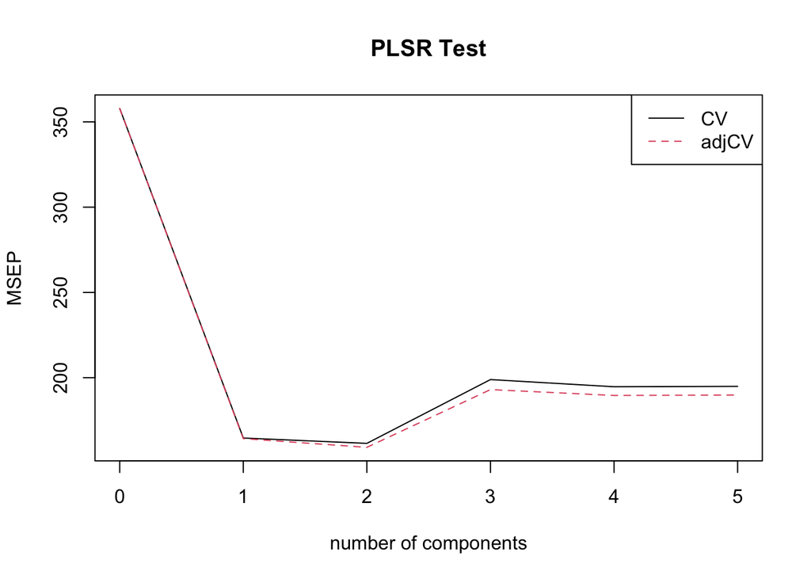

```r
validationplot(pls.fit,val.type="MSEP", legendpos = "topright", main="PLSR Test")
```

```r
pls.pred=predict(pls.fit,x[-train,],ncomp=2)
mean((pls.pred-y[-train])^2)
```

```
## [1] 209.795
```

```r
pls.fit=plsr(VI2~.,data=dati,scale=TRUE,ncomp=2)
summary(pls.fit)
```

```
## Data:    X dimension: 50 5
##  Y dimension: 50 1
## Fit method: kernelpls
## Number of components considered: 2
## TRAINING: % variance explained
##      1 comps  2 comps
## X      46.99    73.11
## VI2    51.43    56.87
```